The purpose of this script is to generate a `spatialExperiment` object using the `imcRtools` package and `cytoimagelist` objects using `cytomapper`. These objects will facilitate the analysis of our imaging mass cytometry data for the early-onset project. The input of this script will be the combined_steinbock folder that was manually curated from multiple runs of Steinbock (Steinbock is ran for every MCD file that we have.)

Overall, 3 batches of IMC were ran: 1 at The Jackson Lab’s Single Cell Biology Core, and 2 at Standard BioTools. It is very importnant to note that the panels across these 3 batches were NOT identifical. As a result, we focussed on just Standard BioTools samples because they had higher quality staining and we wanted to keep the panel consistent. From these samples, Dr. Chris Flynn (board-certified pathologist) and I (Mike Martinez), picked the best of the best samples from the dataset we had.

The code for this repositoy can be found at https://github.com/micmartinez99/Early_Onset_IMC

To get this code onto your computer, simply clone the repository to your machine. You will have to go through and modify all the file paths within this code.

This Rmarkdown file is simply so that whoever is reading this can see the outputs as they were ran and not have to sift through files to find the correct output (although, you could just look at the filepaths and filenames in the code and do find it that way…I thought this might be a little less cumbersome.)

Let’s get started!!

```r
# Load libraries
library(imcRtools)  # For spatialExperiment object generation
library(cytomapper)  # For plotting pixels and cells
library(tidyverse)  # Data manipulation
library(RColorBrewer)  # Color palettes
library(viridis)  # Color palettes
library(scater)  # Single-cell analysis
library(harmony)  # Batch correction
library(BiocSingular)  # Batch correction
library(patchwork)  # Plotting
library(cowplot)  # Plotting
library(dittoSeq)  # Single-cell analysis
library(Rphenograph)  # For clustering
library(igraph)  # For clustering
library(ggplot2)  # For plotting
library(ggpubr)  # For statistical testing on plots
```

In this next chunk, we will read in the steinbock folder (which contains our `cells.csv` file). Upon reading in this folder, we have successfully generated the variable `spe` which is a `spatialExperiment` object. For more information on the architecture of a `spatialExperiment` object, see here: https://www.bioconductor.org/packages/release/bioc/vignettes/SpatialExperiment/inst/doc/SpatialExperiment.html

```r
# Read in the Steinbock folder
spe <- read_steinbock("../Data/combined_steinbock/")
```

```r
# Make sample_id more interpretable
spe$sample_id <- sub("Slide1-6_CRCTMA1_CRCTMA2_", "ROI_", spe$sample_id)
spe$sample_id <- sub("Slide2-5_CRCTMA3_CRCTMA4_", "ROI_", spe$sample_id)

# Check that there are 26 unique sample_id
length(unique(spe$sample_id))
```

```
## [1] 26
```

```r
# For any markers that have a hyphen in their name, replace the hypen with an
# underscore
rownames(spe) <- gsub("\\-", "_", rownames(spe))

# Specify a subset of the channels that will be used for all downstream
# analysis
rowData(spe)$use_channel <- !grepl("DNA1|DNA2|ICSK1|ICSK2|ICSK3|CD14|CD31|CD11c|CD45RA|Perforin|Pan_actin|CD45RA",
    rownames(spe))
```

Using our metadata file `Updated_Metadata.csv`, we can add additional information about each sample to our `spatialExperiment` object. The following code chunk shows how to achieve this.

```r
# Metadata processing
metadata <- read.csv("../Data/Updated_Metadata.csv")

# Add a column for Indication
spe$Indication <- metadata$Indication[match(spe$sample_id, metadata$Sample_ID)]

# Add a column for Patient ID
spe$Patient_ID <- metadata$Patient_ID[match(spe$sample_id, metadata$Sample_ID)]

# Add a column for Source
spe$Source <- metadata$Source[match(spe$sample_id, metadata$Sample_ID)]

# Add a column for Sex
spe$Sex <- metadata$Sex[match(spe$sample_id, metadata$Sample_ID)]

# Add a column for Age
spe$Age <- metadata$Age[match(spe$sample_id, metadata$Sample_ID)]

# Add a column for Diagnosis
spe$Diagnosis <- metadata$Diagnosis[match(spe$sample_id, metadata$Sample_ID)]

# Add a column for Stage
spe$Stage <- metadata$Stage[match(spe$sample_id, metadata$Sample_ID)]

# Add a column for Metastasis
spe$Mets <- metadata$Mets[match(spe$sample_id, metadata$Sample_ID)]

# Add a column for 'Keep'
spe$Keep <- metadata$Analysis[match(spe$sample_id, metadata$Sample_ID)]

# Add a column for diagnosis
spe$Diagnosis <- metadata$Diagnosis[match(spe$sample_id, metadata$Sample_ID)]

# Add a column for stage
spe$Stage <- metadata$Stage[match(spe$sample_id, metadata$Sample_ID)]
```

As aforementioned, we decided that some samples were not fit for analysis, so there is a column in out metadata called “keep”. Here, we will subset our `spatialExperiment` object. To subset, we can essentially treat the colData of `spe` as a dataframe and subset based on the columns.

```r
# Subset the spe object based on the 'keep' vector
spe <- spe[, spe$Keep == "Keep"]
unique(spe$sample_id)
```

```
##  [1] "ROI_022" "ROI_024" "ROI_025" "ROI_026" "ROI_027" "ROI_028" "ROI_031"
##  [8] "ROI_032" "ROI_033" "ROI_034" "ROI_035" "ROI_036" "ROI_037" "ROI_038"
## [15] "ROI_001" "ROI_002" "ROI_003" "ROI_005" "ROI_006" "ROI_008"
```

```r
# Set cell names
colnames(spe) <- paste0("cell", seq_len(ncol(spe)))

# Filter the metadata
meta <- metadata[metadata$Analysis == "Keep", ]
rownames(meta) <- meta$Sample_ID
```

Now that we have all of our metadata appended to the `spe` object, we can assign color-vectors for each metadata category that will be used for plotting downstream. We do this for consistency sake. These can always be changed later if you think they look ugly!

```r
# Initialize an empty list to hold the color vectors in the spe object
color_vectors <- list()

# Set colors for EOCRC and LOCRC
indication_colors <- c(EOCRC = "firebrick2", LOCRC = "cyan3")

sex_colors <- c(M = "black", F = "grey")

source_colors <- c(JDH = "green", WBH = "purple")

# Append vectors to color list
color_vectors$Indication <- indication_colors
color_vectors$Sex <- sex_colors
color_vectors$Source <- source_colors

# Append color list to metadata slot in spe
metadata(spe)$color_vectors <- color_vectors
```

Our `spe` object is now pre-processed (note, I say “pre-processed” because much like a single-cell experiment, as we add aspects of the analysis, our `spatialExperiment` object will gain new slots and get bigger and bigger. This will be the “processing”) We can now shift our focus to the images and masks of the IMC experiment. These images and masks will interface with the package `cytomapper` through objects called `cytoImageLists`. For more on the `cytoImageList` class, see here: https://www.bioconductor.org/packages/release/bioc/vignettes/cytomapper/inst/doc/cytomapper.html

A critical step is ensuring that the sample names and number of samples are the same between your `cytoImageList` objects and `spe` object.

```r
# Read in the Images
img <- loadImages("../Data/combined_steinbock/img/")
```

```
## All files in the provided location will be read in.
```

```r
# Adjust sample IDs for images/masks to match spe
names(img) <- sub("Slide1-6_CRCTMA1_CRCTMA2_", "ROI_", names(img))
names(img) <- sub("Slide2-5_CRCTMA3_CRCTMA4_", "ROI_", names(img))

# Set a vector of the samples that we are keeping (only WBH and only tumor)
keep <- metadata[metadata$Analysis == "Keep", ]$Sample_ID

# Filter the images based on the vector of samples to keep
img <- img[names(img) %in% keep]

# Read in the masks
masks <- loadImages("../Data/combined_steinbock/masks_deepcell/", as.is = TRUE)
```

```
## All files in the provided location will be read in.
```

```r
# Adjust sample IDs for images/masks to match spe
names(masks) <- sub("Slide1-6_CRCTMA1_CRCTMA2_", "ROI_", names(masks))
names(masks) <- sub("Slide2-5_CRCTMA3_CRCTMA4_", "ROI_", names(masks))

# Filter the masks based on the vector of samples to keep
masks <- masks[names(masks) %in% keep]

# Ensure that channel names for images match the spe object
channelNames(img) <- rownames(spe)

# Check that all images/masks are there and sample_ids are the same as spe
length(names(img))
```

```
## [1] 20
```

```r
names(img)
```

```
##  [1] "ROI_022" "ROI_024" "ROI_025" "ROI_026" "ROI_027" "ROI_028" "ROI_031"
##  [8] "ROI_032" "ROI_033" "ROI_034" "ROI_035" "ROI_036" "ROI_037" "ROI_038"
## [15] "ROI_001" "ROI_002" "ROI_003" "ROI_005" "ROI_006" "ROI_008"
```

```r
length(names(masks))
```

```
## [1] 20
```

```r
names(masks)
```

```
##  [1] "ROI_022" "ROI_024" "ROI_025" "ROI_026" "ROI_027" "ROI_028" "ROI_031"
##  [8] "ROI_032" "ROI_033" "ROI_034" "ROI_035" "ROI_036" "ROI_037" "ROI_038"
## [15] "ROI_001" "ROI_002" "ROI_003" "ROI_005" "ROI_006" "ROI_008"
```

```r
# Set image names across images/masks and spe
mcols(img) <- mcols(masks) <- DataFrame(sample_id = names(img))
```

We now have two `cytoImageList` objects, `img` and `masks`. Just like with the `spatialExperiment` object, we need to append the metadata to our `cytoImageList` objects.

```r
# Get metadata in the same order as the images
rownames(metadata) <- metadata$Sample_ID
metadata <- metadata[names(img), ]

# Only keep the samples we want to include
metadata <- metadata[metadata$Analysis == "Keep", ]
metadata <- metadata[names(img), ]

# Generate vectors to append metadata to images
EorL <- metadata$Indication
Pat <- metadata$Patient_ID
Sex <- metadata$Sex
Diag <- metadata$Diagnosis
Stag <- metadata$Stage
Age <- metadata$Age
Source <- metadata$Source

# Assign the metadata to the images and masks as well
mcols(img) <- mcols(masks) <- DataFrame(sample_id = names(img), Indication = EorL,
    Patient = Pat, Sex = Sex, Diagnosis = Diag, Stage = Stag, Age = Age, Source = Source)

# Add a label slot to mcols for downstream plotting
mcols(img)$Label <- paste(paste(paste(mcols(img)$sample_id, mcols(img)$Sex, sep = " - "),
    mcols(img)$Source, sep = "\n"), mcols(img)$Indication, sep = " - ")
mcols(masks)$Label <- paste(paste(paste(mcols(masks)$sample_id, mcols(masks)$Sex,
    sep = " - "), mcols(masks)$Source, sep = "\n"), mcols(masks)$Indication, sep = " - ")
```

Now, we have successfully generated our `spatialExperiment` and `cytoImageList` objects. Now, we can start processing our `spatialExperiment` object. First, we will transform the expression values by using the hyperbolic sine transformation which is typical of cytometry data. For this, we use a cofactor of 1. For flow-cytometry data, we would normally use 5, but since imaging-mass cytometry is different, 1 seems to work best. You can read more about this in the following manuscript: https://www.biorxiv.org/content/10.1101/2023.02.21.526083v1

We achieve this by creating a new assay slot in our `spatialExperiment` object called “exprs”. Next, we will perform dimensionality reduction using the UMAP algorithm to visualize our dataset in 2-dimensional space. Doing this can identify if there are any troublesome batch effects that need to be taken care of.

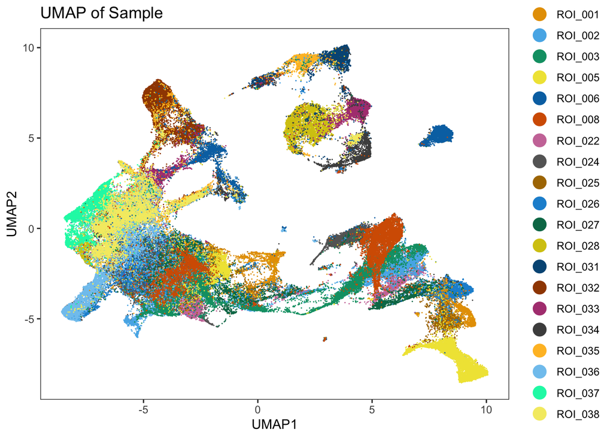

```r
# Transform the counts to expression values
assay(spe, "exprs") <- asinh(counts(spe)/1)

# Run Dimensionality reduction on the spe object
set.seed(30161999)
spe <- runUMAP(spe, subset_row = rowData(spe)$use_channel, exprs_values = "exprs")

# Assess the UMAP
dittoDimPlot(spe, var = "sample_id", reduction.use = "UMAP", size = 0.2) + ggtitle("UMAP of Sample")
```

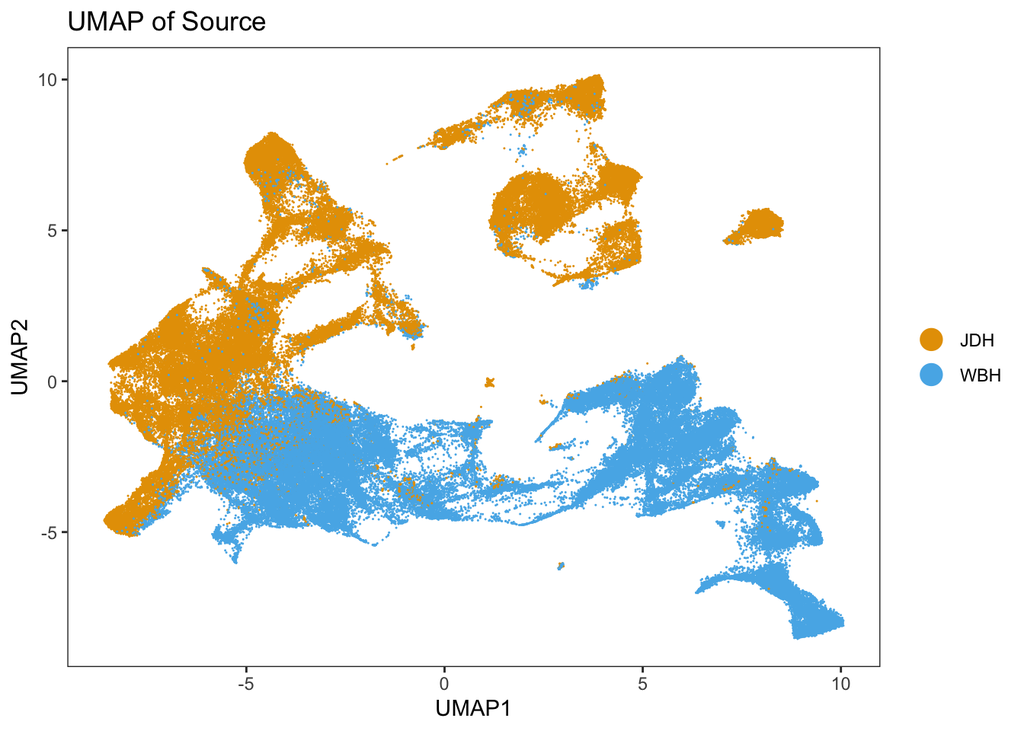

```r
dittoDimPlot(spe, var = "Source", reduction.use = "UMAP", size = 0.2) + ggtitle("UMAP of Source")
```

As evident in the UMAP, each sample’s cells are clustering independently from other ROIs. This is essentially a “batch” effect. Additionally, samples from JDH cluster separately from WBH. We need to address this batch effect before moving on or else out data will be uninterpretable. To handle this, we will make use of the `Harmony` package and algorithm. To read about how this algorithm works, see here: https://www.nature.com/articles/s41592-019-0619-0

The PCA step might cause a warning message such as “Warning in check_numbers (x, k = k, nu = nu, nv = nv): more singular values/vectors requested than available. You can ignore this!

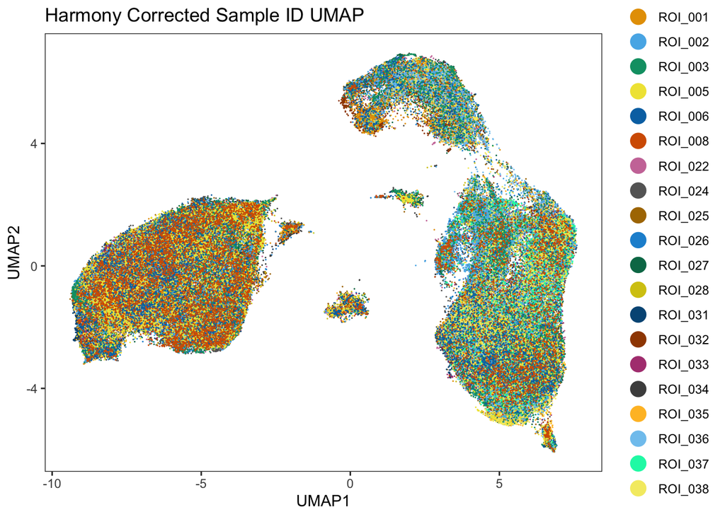

```r
# Run PCA on the data to prepare for Harmony batch correction
set.seed(3061999)
spe <- runPCA(spe, subset_row = rownames(spe)[rowData(spe)$use_channel], exprs_values = "exprs",
    ncomponents = 50, BSPARAM = ExactParam())

# Run Harmony correction
set.seed(3061999)
out <- RunHarmony(spe, group.by.vars = c("sample_id", "Source"))
reducedDim(spe, "Harmony") <- reducedDim(out, "HARMONY")
spe <- runUMAP(spe, dimred = "Harmony", name = "UMAP_Harmony")

# Assess the batch correction
dittoDimPlot(spe, var = "sample_id", reduction.use = "UMAP_Harmony", size = 0.2) +
    ggtitle("Harmony Corrected Sample ID UMAP")
```

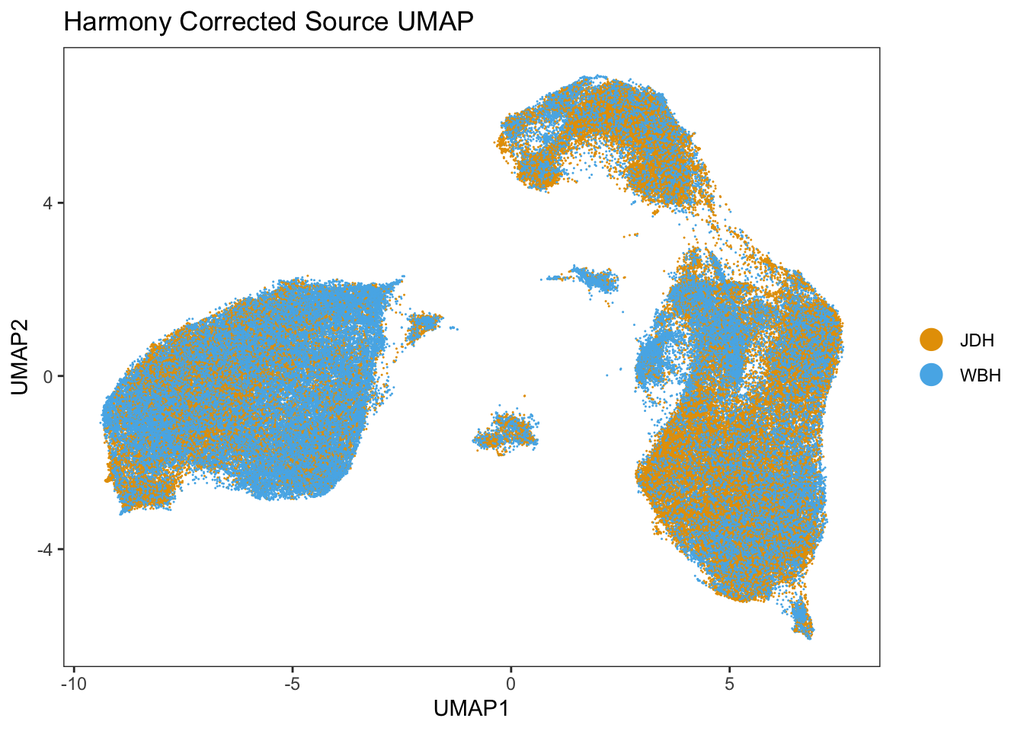

```r
# Assess the batch correction
dittoDimPlot(spe, var = "Source", reduction.use = "UMAP_Harmony", size = 0.2) + ggtitle("Harmony Corrected Source UMAP")
```